# Chapter 3 Predict

Mike Aguilar

## Forecast via Density

If we know the distribution, then we can “predict” what might happen next.

### Prob(Ret<.01)

What is the chance of getting a return smaller than .01? Let’s calibrate the mean and variance of Ford.

```r
rm(list=ls()) # clear workspace
cat("\014")  # clear console
```

```r
library(quantmod)
library(corrplot)
Tickers<-'F'
startd = "2015-01-01"
endd = "2021-04-30"
TickersReturned<-getSymbols(Tickers,from=startd,to=endd,src='yahoo')
F$Returns = F$F.Adjusted/lag.xts(F$F.Adjusted,k=1)-1
mu = mean(na.omit(F$Returns))
sigma = sd(na.omit(F$Returns))
x=.01
ProbX = pnorm(x,mean = mu, sd = sigma)
print(ProbX)
```

```
## [1] 0.6819564
```

### Prob(Ret>.01)

What is the chance of getting a return greater than .01? Let’s calibrate the mean and variance of Ford.

```r
rm(list=ls()) # clear workspace
cat("\014")  # clear console
```

```r
library(quantmod)
library(corrplot)
Tickers<-'F'
startd = "2015-01-01"
endd = "2021-04-30"
TickersReturned<-getSymbols(Tickers,from=startd,to=endd,src='yahoo')
F$Returns = F$F.Adjusted/lag.xts(F$F.Adjusted,k=1)-1
mu = mean(na.omit(F$Returns))
sigma = sd(na.omit(F$Returns))
x=.01
ProbX = 1-pnorm(x,mean = mu, sd = sigma)
print(ProbX)
```

```
## [1] 0.3180436
```

### Prob(.01<Ret<.05)

What is the chance of getting a return between .01 and .05? Let’s calibrate the mean and variance of Ford.

```r
rm(list=ls()) # clear workspace
cat("\014")  # clear console
```

```r
library(quantmod)
library(corrplot)
Tickers<-'F'
startd = "2015-01-01"
endd = "2021-04-30"
TickersReturned<-getSymbols(Tickers,from=startd,to=endd,src='yahoo')
F$Returns = F$F.Adjusted/lag.xts(F$F.Adjusted,k=1)-1
mu = mean(na.omit(F$Returns))
sigma = sd(na.omit(F$Returns))
x=.01
y = .05
ProbX = pnorm(x,mean = mu, sd = sigma)
ProbY = pnorm(y,mean = mu, sd = sigma)
Prob = ProbY - ProbX
print(Prob)
```

```
## [1] 0.3100045
```

### Prob(Ret<?)=70%

If there is a 70% chance of getting a return less than y. What is y? Let’s calibrate the mean and variance of Ford.

```r
rm(list=ls()) # clear workspace
cat("\014")  # clear console
```

```r
library(quantmod)
library(corrplot)
Tickers<-'F'
startd = "2015-01-01"
endd = "2021-04-30"
TickersReturned<-getSymbols(Tickers,from=startd,to=endd,src='yahoo')
F$Returns = F$F.Adjusted/lag.xts(F$F.Adjusted,k=1)-1
mu = mean(na.omit(F$Returns))
sigma = sd(na.omit(F$Returns))
p = .7
X = qnorm(p,mean = mu, sd = sigma)
print(X)
```

```
## [1] 0.01105946
```

### Prob(Ret>?)=70%

If there is a 70% chance of getting a return greater than y. What is y? Let’s calibrate the mean and variance of Ford.

```r
rm(list=ls()) # clear workspace
cat("\014")  # clear console
```

```r
library(quantmod)
library(corrplot)
Tickers<-'F'
startd = "2015-01-01"
endd = "2021-04-30"
TickersReturned<-getSymbols(Tickers,from=startd,to=endd,src='yahoo')
F$Returns = F$F.Adjusted/lag.xts(F$F.Adjusted,k=1)-1
mu = mean(na.omit(F$Returns))
sigma = sd(na.omit(F$Returns))
p = .7
X = qnorm(1-p,mean = mu, sd = sigma)
print(X)
```

```
## [1] -0.01063285
```

### Prob(-.01<Ret<Y)=25%

If we have a 25% prob of getting return between -0.01 and y. What is y? Let’s calibrate the mean and variance of Ford.

```r
rm(list=ls()) # clear workspace
cat("\014")  # clear console
```

```r
library(quantmod)
library(corrplot)
Tickers<-'F'
startd = "2015-01-01"
endd = "2021-04-30"
TickersReturned<-getSymbols(Tickers,from=startd,to=endd,src='yahoo')
F$Returns = F$F.Adjusted/lag.xts(F$F.Adjusted,k=1)-1
mu = mean(na.omit(F$Returns))
sigma = sd(na.omit(F$Returns))
p = .25
x = -.01
ProbX = pnorm(x,mean = mu, sd = sigma)
y = qnorm(p+ProbX,mean = mu, sd = sigma)
print(y)
```

```
## [1] 0.003373698
```

## Simulation

### Simulate Returns

Simulate returns calibrated to MSFT daily returns. We assume normal distribution.

```r
knitr::opts_chunk$set(echo = TRUE)
rm(list=ls()) # clear workspace
cat("\014")  # clear console
```

```r
library("tidyquant")
ticker = 'MSFT' # asset ticker
start_date = '2017-01-01' # data start date
end_date = '2021-03-01' # data end date
data_src = 'yahoo' # data source
getSymbols(ticker,from = start_date,to = end_date, src=data_src)
```

```
## [1] "MSFT"
```

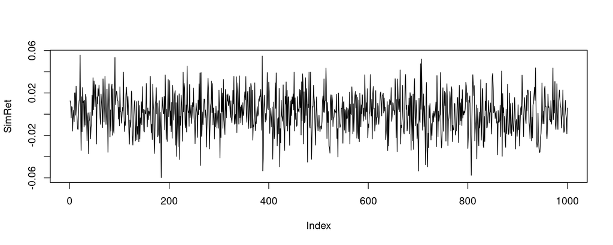

```r
library(PerformanceAnalytics)
MSFT$Return<-MSFT$MSFT.Adjusted/lag.xts(MSFT$MSFT.Adjusted,k=1) - 1 # use lag.xts to obtain the lag for xts data
MSFT = na.omit(MSFT)
MeanMSFT=mean(MSFT$Return)
SigmaMSFT=sd(MSFT$Return)
T = 1000
SimRet<-rnorm(T,mean=MeanMSFT,sd=SigmaMSFT)
plot(SimRet,type="l")
```

### Simulate Returns with Seed

Simulate returns calibrated to MSFT daily returns and using a specific seed. We assume normal distribution.

```r
knitr::opts_chunk$set(echo = TRUE)
rm(list=ls()) # clear workspace
cat("\014")  # clear console
```

```r
library("tidyquant")
ticker = 'MSFT' # asset ticker
start_date = '2017-01-01' # data start date
end_date = '2021-03-01' # data end date
data_src = 'yahoo' # data source
getSymbols(ticker,from = start_date,to = end_date, src=data_src)
```

```
## [1] "MSFT"
```

```r
library(PerformanceAnalytics)
MSFT$Return<-MSFT$MSFT.Adjusted/lag.xts(MSFT$MSFT.Adjusted,k=1) - 1 # use lag.xts to obtain the lag for xts data
MSFT = na.omit(MSFT)
MeanMSFT=mean(MSFT$Return)
SigmaMSFT=sd(MSFT$Return)
T = 1000
set.seed(10)
SimRet10<-rnorm(T,mean=MeanMSFT,sd=SigmaMSFT)
set.seed(11)
SimRet11<-rnorm(T,mean=MeanMSFT,sd=SigmaMSFT)
todisplay<-cbind(SimRet10,SimRet11)
head(todisplay)
```

```
##          SimRet10     SimRet11
## [1,]  0.001824892 -0.009217572
## [2,] -0.001851214  0.001967015
## [3,] -0.023348023 -0.025977860
## [4,] -0.009364918 -0.023190888
## [5,]  0.006819338  0.022826691
## [6,]  0.008544207 -0.015431140
```

### Simulate Multiple Return Paths

Simulate multiple return paths calibrated to MSFT daily returns. We assume normal distributions.

```r
knitr::opts_chunk$set(echo = TRUE)
rm(list=ls()) # clear workspace
cat("\014")  # clear console
```

```r
library("tidyquant")
ticker = 'MSFT' # asset ticker
start_date = '2017-01-01' # data start date
end_date = '2021-03-01' # data end date
data_src = 'yahoo' # data source
getSymbols(ticker,from = start_date,to = end_date, src=data_src)
```

```
## [1] "MSFT"
```

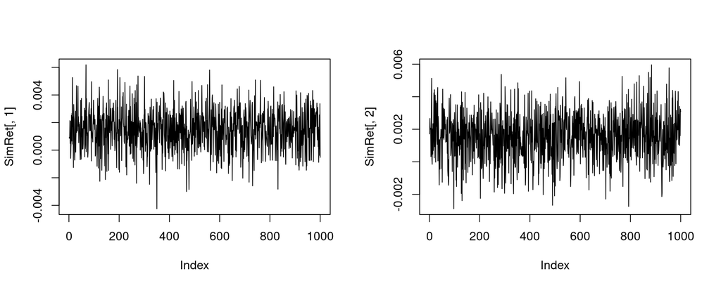

```r
library(PerformanceAnalytics)
MSFT$Return<-MSFT$MSFT.Adjusted/lag.xts(MSFT$MSFT.Adjusted,k=1) - 1 # use lag.xts to obtain the lag for xts data
MSFT = na.omit(MSFT)
H = 2  # of paths to simulate
Means=rep(mean(MSFT$Return),H)
Sigmas=rep(sd(MSFT$Return),H)
Moments=cbind(Means,Sigmas)
T = 1000 # size of each path
func<-function(x) rnorm(T,mean=Moments[1],sd=Moments[1])
SimRet<-as.data.frame(apply(Moments,1,FUN=func))
par(mfrow=c(1,2))
plot(SimRet[,1],type="l")
plot(SimRet[,2],type="l")
```

### Simulate Correlated Returns

Simulate normal returns calibrated to MSFT & GE daily returns.

```r
knitr::opts_chunk$set(echo = TRUE)
rm(list=ls()) # clear workspace
cat("\014")  # clear console
```

```r
library("tidyquant")
Tickers = c('MSFT','GE') # asset tickers
start_date = '2017-01-01' # data start date
end_date = '2021-03-01' # data end date
data_src = 'yahoo' # data source
getSymbols(Tickers,from = start_date,to = end_date, src=data_src)
```

```
## [1] "MSFT" "GE"
```

```r
library(PerformanceAnalytics)
Returns = do.call(merge,lapply(Tickers, function(x)
        periodReturn(Ad(get(x)),period='daily',type='arithmetic')))
Returns = na.omit(Returns[-1,])
colnames(Returns)<-Tickers
Means<-as.numeric(lapply(Returns,FUN=mean))
Means
```

```
## [1]  0.0014854174 -0.0004071208
```

```r
V<-cov(Returns)
V
```

```
##              MSFT           GE
## MSFT 0.0003279365 0.0001634276
## GE   0.0001634276 0.0007530284
```

```r
library(mvtnorm)
T = 10000
SimReturns<-rmvnorm(T,Means,V)
cov(SimReturns)
```

```
##              [,1]         [,2]
## [1,] 0.0003277859 0.0001548617
## [2,] 0.0001548617 0.0007441121
```

```r
apply(SimReturns,2,FUN=mean)
```

```
## [1]  0.0016385868 -0.0006632703
```

### Simulate Portofolio Correlated Return

### Sim. Port. Correlated Ret.

Simulate normal returns calibrated to MSFT & GE daily returns.

```r
knitr::opts_chunk$set(echo = TRUE)
rm(list=ls()) # clear workspace
cat("\014")  # clear console
```

```r
library("tidyquant")
Tickers = c('MSFT','GE') # asset tickers
start_date = '2017-01-01' # data start date
end_date = '2021-03-01' # data end date
data_src = 'yahoo' # data source
getSymbols(Tickers,from = start_date,to = end_date, src=data_src)
```

```
## [1] "MSFT" "GE"
```

```r
library(PerformanceAnalytics)
Returns = do.call(merge,lapply(Tickers, function(x)
        periodReturn(Ad(get(x)),period='daily',type='arithmetic')))
Returns = na.omit(Returns[-1,])
colnames(Returns)<-Tickers
Means<-as.numeric(lapply(Returns,FUN=mean))
V<-cov(Returns)
C<-cor(Returns)
TargetMean=Means[1]+Means[2]
TargetMean
```

```
## [1] 0.001078296
```

```r
TargetVariance=V[1,1]+V[2,2]+2*C[1,2]*sqrt(V[1,1])*sqrt(V[2,2])
sqrt(TargetVariance)
```

```
## [1] 0.03752093
```

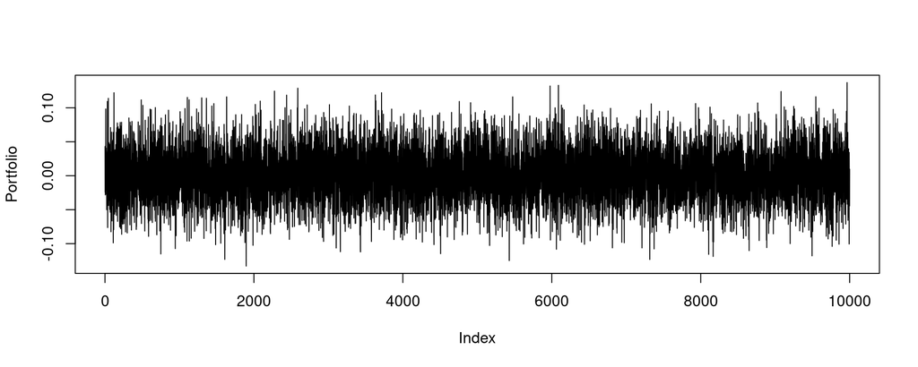

```r
T = 10000
Portfolio<-rnorm(T,mean=TargetMean,sd=sqrt(TargetVariance))
plot(Portfolio,type="l")
```

```r
mean(Portfolio)
```

```
## [1] 0.001330043
```

```r
sd(Portfolio)
```

```
## [1] 0.03716607
```

### Geometric Random Walk

Let’s create a random walk calibrated to the mean and variance of MSFT historical returns.

```r
knitr::opts_chunk$set(echo = TRUE)
rm(list=ls()) # clear workspace
cat("\014")  # clear console
```

```r
library("tidyquant")
ticker = 'MSFT' # asset ticker
start_date = '2017-01-01' # data start date
end_date = '2021-03-01' # data end date
data_src = 'yahoo' # data source
getSymbols(ticker,from = start_date,to = end_date, src=data_src)
```

```
## [1] "MSFT"
```

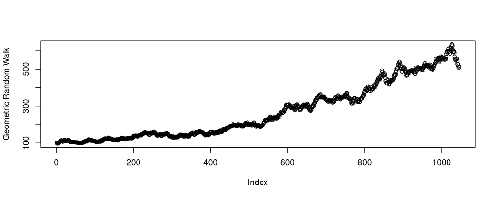

```r
library(PerformanceAnalytics)
MSFT$Return<-MSFT$MSFT.Adjusted/lag.xts(MSFT$MSFT.Adjusted,k=1) - 1 # use lag.xts to obtain the lag for xts data
MSFT<-na.omit(MSFT)
MSFTMean=mean(MSFT$Return)
MSFTSd=sd(MSFT$Return)
T=dim(MSFT$Return)[1]
r<-as.data.frame(rnorm(T,mean=MSFTMean,sd=MSFTSd))
colnames(r)<-c('r')
StartPrice = 100
Price<-r
Price<-StartPrice*(exp(cumsum(Price)))
Price<-rbind(StartPrice,Price)
colnames(Price)<-c('Price')

plot(Price$Price,ylab = 'Geometric Random Walk')
```

## Time Series Forecasting

### ARIMA One-Step Ahead

```r
### Houesekeeping
rm(list=ls()) # clear workspace
cat("\014")  # clear console
```

```r
library(quantmod)
startd<-"1990-01-01"
endd<-"2020-12-31"
Ticker = "GDPC1"
getSymbols(Ticker,from=startd,to=endd,src='FRED')
```

```
## [1] "GDPC1"
```

```r
Growth<-diff(log(GDPC1))
Growth<-na.omit(Growth)
colnames(Growth)=c("Growth")
# Split Data
Train <-Growth["/2014"]
Test<-Growth["2015/"]
```

```r
### Dynamic One-Step Ahead Forecast with ARIMA Model
library(forecast)
fit<-auto.arima(Train)

# Make 1-step ahead forecast
StepNum = 1
ARIMAForecast <- forecast(fit, h = StepNum) # h is the forecast step number
ARIMAForecast
```

```
##     Point Forecast        Lo 80      Hi 80       Lo 95      Hi 95
## 272    0.007302312 -0.004084941 0.01868956 -0.01011299 0.02471761
```

### ARIMA Multi-Step Ahead

```r
### Houesekeeping
rm(list=ls()) # clear workspace
cat("\014")  # clear console
```

```r
### Load Data
#library(Quandl)
#Quandl_key = read.csv("quandlkey.csv",stringsAsFactors=FALSE)$Key
#Quandl.api_key(Quandl_key)
#startd<-"1990-01-01"
#endd<-"2018-12-31"
#freq<-"quarterly"
#GDP <- Quandl("FRED/GDPC1", type="ts",start_date=startd, end_date=endd)
#GDPGrowth <- diff(log(GDP)) # calculate log growth rate
#GDPGrowth <- na.omit(GDPGrowth) # get rid of the NAs

library(quantmod)
startd<-"1990-01-01"
endd<-"2020-12-31"
Ticker = "GDPC1"
getSymbols(Ticker,from=startd,to=endd,src='FRED')
```

```
## [1] "GDPC1"
```

```r
Growth<-diff(log(GDPC1))
Growth<-na.omit(Growth)
colnames(Growth)=c("Growth")
# Split Data
Train <-Growth["/2014"]
Test<-Growth["2015/"]
```

```r
### Dynamic Multi-Step Ahead Forecast with ARIMA Model
library(forecast)
fit<-auto.arima(Train)

# Make 5-step ahead forecast
StepNum = 5
ARIMAForecast <- forecast(fit, h = StepNum) # h is the forecast step number
ARIMAForecast
```

```
##     Point Forecast        Lo 80      Hi 80       Lo 95      Hi 95
## 272    0.007302312 -0.004084941 0.01868956 -0.01011299 0.02471761
## 273    0.006537313 -0.005430953 0.01850558 -0.01176657 0.02484120
## 274    0.007493945 -0.004860405 0.01984829 -0.01140040 0.02638829
## 275    0.007738037 -0.004641031 0.02011711 -0.01119411 0.02667019
## 276    0.007800320 -0.004580357 0.02018100 -0.01113429 0.02673493
```

### GARCH One-Step Ahead

```r
### Housekeeping
rm(list=ls()) # clear workspace
cat("\014")  # clear console
```

```r
### Load Date
library(quantmod)
startd <-"2012-01-01"
endd <-"2015-12-31"
ticker <- "^GSPC"
Prices <- Ad(getSymbols(ticker, from = startd, to = endd, auto.assign = FALSE)) # get the adjusted closed price
Returns <- diff(log(Prices)) # get daily log-return
Returns <- na.omit(Returns)
names(Returns)<-"Actual Return"

# Remove mean from data
# Note: means of daily stock returns are VERY small, this step does not matter much
Returns <- Returns - mean(Returns)

# Squared returns/volatility target
SqReturns <- Returns^2

# Split training and test data
Train <- Returns["/2015-11-29"]
Test <- Returns["2015-11-30/"]
```

```r
### Specify Model: GARCH(1,1)
library(rugarch)
spec <- ugarchspec(variance.model=list(model="sGARCH", garchOrder=c(1,1)),
                   mean.model=list(include.mean = F, armaOrder=c(0,0)),
                   distribution.model="norm")

# Estimate coefficients
fit <- ugarchfit(spec = spec, data = Returns, out.sample = length(Test)) # note that out-of-sample data is excluded by indicating out.sample = length(Test)
coef(fit)
```

```
##        omega       alpha1        beta1
## 7.453310e-06 1.503894e-01 7.315831e-01
```

```r
### Make Static One-Step Ahead Forecast with GARCH Model
Forecast <- ugarchforecast(fitORspec = fit, n.ahead = 1, n.roll=length(Test)-1)

# Forecast for volatility(sigma)
Forecast_Volatility <- data.frame(t(sigma(Forecast)))
names(Forecast_Volatility) <- rownames(sigma(Forecast))
Forecast_Volatility # Note that the date shown is when the forecast was made
```

```
##                    T+1
## 2015-11-27 0.006317413
## 2015-11-30 0.006372429
## 2015-12-01 0.007255538
## 2015-12-02 0.008122455
## 2015-12-03 0.009452882
## 2015-12-04 0.011490102
## 2015-12-07 0.010605652
## 2015-12-08 0.009853295
## 2015-12-09 0.009418553
## 2015-12-10 0.008533645
## 2015-12-11 0.011019905
## 2015-12-14 0.009951531
## 2015-12-15 0.009756997
## 2015-12-16 0.010309859
## 2015-12-17 0.011043898
## 2015-12-18 0.012157077
## 2015-12-21 0.011114259
## 2015-12-22 0.010401169
## 2015-12-23 0.010381048
## 2015-12-24 0.009324294
## 2015-12-28 0.008492472
## 2015-12-29 0.008691667
```

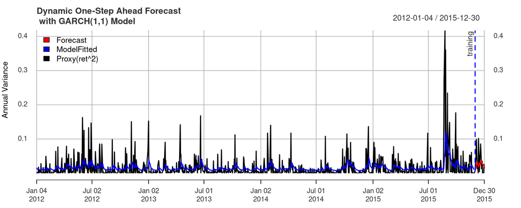

```r
### Plot Forecasts
# Variance
PlotVariance = cbind(xts(Forecast_Volatility^2, order.by=index(Test)),
                       sigma(fit)^2, SqReturns)
PlotVariance = 252*PlotVariance
colnames(PlotVariance) <- c("Forecast", "ModelFitted", "Proxy(ret^2)")
# Plot
{plot(PlotVariance, col = c("red","blue","black"), lwd = 2, ylab = "Annual Variance",
     main = "Dynamic One-Step Ahead Forecast \n with GARCH(1,1) Model", legend.loc = "topleft")
addEventLines(xts("training", index(Test)[1]), srt=90, pos=2, lty = 2, lwd = 2, col = "blue") }
```

```r
### MSE for GARCH
MSE <- rbind("GARCH(1,1)" = c(mean((SqReturns - PlotVariance$ModelFitted)^2,na.rm = T),
                              mean((SqReturns - PlotVariance$Forecast)^2, na.rm = T)))
colnames(MSE) <- c("In-sample MSE", "Out-of-sample MSE")
print(MSE)
```

```
##            In-sample MSE Out-of-sample MSE
## GARCH(1,1)  0.0003554086      0.0005995473
```

### GARCH Multi-Step Ahead

```r
### Housekeeping
rm(list=ls()) # clear workspace
cat("\014")  # clear console
```

```r
### Load Date
library(quantmod)
startd <-"2012-01-01"
endd <-"2015-12-31"
ticker <- "^GSPC"
Prices <- Ad(getSymbols(ticker, from = startd, to = endd, auto.assign = FALSE)) # get the adjusted closed price
Returns <- diff(log(Prices)) # get daily log-return
Returns <- na.omit(Returns)
names(Returns)<-"Actual Return"

# Remove mean from data
# Note: means of daily stock returns are VERY small, this step does not matter much
Returns <- Returns - mean(Returns)

# Squared returns/volatility target
SqReturns <- Returns^2

# Split training and test data
Train <- Returns["/2015-11-29"]
Test <- Returns["2015-11-30/"]
```

```r
### Specify model: GARCH(1,1)
library(rugarch)
spec <- ugarchspec(variance.model=list(model="sGARCH", garchOrder=c(1,1)),
                   mean.model=list(include.mean = F, armaOrder=c(0,0)),
                   distribution.model="norm")

# Estimate coefficients
fit <- ugarchfit(spec = spec, data = Returns, out.sample = length(Test)) # note that out-of-sample data is excluded by indicating out.sample = length(Test)
coef(fit)
```

```
##        omega       alpha1        beta1
## 7.453310e-06 1.503894e-01 7.315831e-01
```

```r
### Make Static 5-Step Ahead Forecast
StepNum = 5
StaticForecast <- ugarchforecast(fitORspec = fit, n.ahead = StepNum, n.roll=length(Test)-StepNum) # n.roll is the number of days you want to forecast


# Forecast for volatility(sigma)
StaticForecast_Volatility <- data.frame(t(sigma(StaticForecast)))
names(StaticForecast_Volatility) <- rownames(sigma(StaticForecast))
StaticForecast_Volatility # Note that the date shown is when the forecast was made, so 0.00771 is the one-step forecast made in 2014-12-31, which is the forecast for 2015-01-02 SP500 return. The first 5-step ahead forecast is made for 2015-01-08, which is made in 2014-12-31.
```

```
##                    T+1         T+2         T+3         T+4         T+5
## 2015-11-27 0.006317413 0.006530894 0.006713547 0.006870613 0.007006219
## 2015-11-30 0.006372429 0.006577865 0.006753871 0.006905381 0.007036301
## 2015-12-01 0.007255538 0.007340493 0.007414614 0.007479376 0.007536033
## 2015-12-02 0.008122455 0.008101902 0.008083730 0.008067670 0.008053479
## 2015-12-03 0.009452882 0.009287826 0.009139777 0.009007183 0.008888597
## 2015-12-04 0.011490102 0.011130744 0.010803885 0.010507170 0.010238341
## 2015-12-07 0.010605652 0.010327509 0.010075825 0.009848509 0.009643578
## 2015-12-08 0.009853295 0.009647889 0.009463026 0.009296932 0.009147939
## 2015-12-09 0.009418553 0.009257015 0.009112167 0.008982477 0.008866519
## 2015-12-10 0.008533645 0.008466480 0.008406797 0.008353804 0.008306785
## 2015-12-11 0.011019905 0.010703203 0.010415892 0.010155748 0.009920648
## 2015-12-14 0.009951531 0.009736409 0.009542654 0.009368442 0.009212058
## 2015-12-15 0.009756997 0.009561182 0.009385088 0.009226990 0.009085268
## 2015-12-16 0.010309859 0.010059870 0.009834113 0.009630612 0.009447492
## 2015-12-17 0.011043898 0.010724992 0.010435641 0.010173613 0.009936779
## 2015-12-18 0.012157077 0.011738995 0.011357493 0.011010054 0.010694258
## 2015-12-21 0.011114259 0.010788907 0.010493587 0.010226047 0.009984136
## 2015-12-22 0.010401169 0.010142430 0.009908625 0.009697738 0.009507860
```

```r
#  5-step ahead volatility forecasts over the test set
FiveStep.Vol<-xts(StaticForecast_Volatility$`T+5`,order.by=
                    index(Test[StepNum:length(Test)]))
data.frame(FiveStep.Vol)
```

```
##            FiveStep.Vol
## 2015-12-04  0.007006219
## 2015-12-07  0.007036301
## 2015-12-08  0.007536033
## 2015-12-09  0.008053479
## 2015-12-10  0.008888597
## 2015-12-11  0.010238341
## 2015-12-14  0.009643578
## 2015-12-15  0.009147939
## 2015-12-16  0.008866519
## 2015-12-17  0.008306785
## 2015-12-18  0.009920648
## 2015-12-21  0.009212058
## 2015-12-22  0.009085268
## 2015-12-23  0.009447492
## 2015-12-24  0.009936779
## 2015-12-28  0.010694258
## 2015-12-29  0.009984136
## 2015-12-30  0.009507860
```

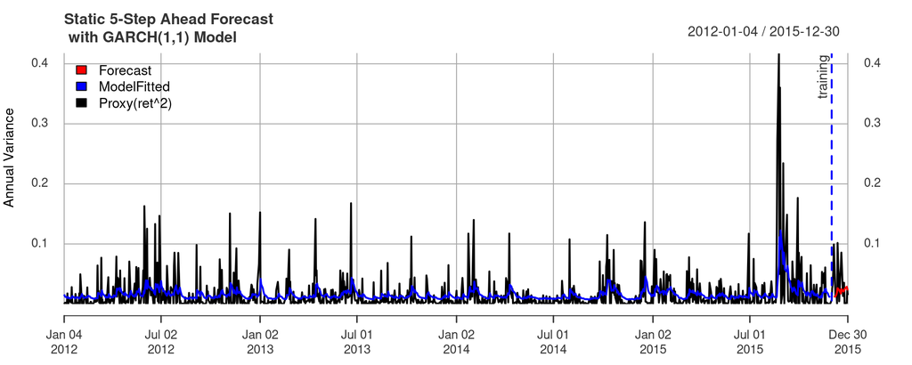

```r
### Plot 5-Step Ahead Forecasts
# Variance
PlotVariance = cbind(FiveStep.Vol**2, sigma(fit)**2, SqReturns)
PlotVariance = 252*PlotVariance
colnames(PlotVariance) <- c("Forecast", "ModelFitted", "Proxy(ret^2)")
# Plot
{plot(PlotVariance, col = c("red","blue","black"), lwd = 2, ylab = "Annual Variance",
     main = "Static 5-Step Ahead Forecast \n with GARCH(1,1) Model", legend.loc = "topleft")
addEventLines(xts("training", index(Test)[1]), srt=90, pos=2, lty = 2, lwd = 2, col = "blue") }
```

```r
### MSE for GARCH
MSE <- rbind("GARCH(1,1)" = c(mean((SqReturns - PlotVariance$ModelFitted)**2,na.rm = T),
                              mean((SqReturns - PlotVariance$Forecast)**2, na.rm = T)))
colnames(MSE) <- c("In-sample MSE", "Out-of-sample MSE")
print(MSE)
```

```
##            In-sample MSE Out-of-sample MSE
## GARCH(1,1)  0.0003554086      0.0004489244
```

### ARMA-GARCH

```r
### Housekeeping
rm(list=ls()) # clear workspace
cat("\014")  # clear console
```

```r
### Load Date
library(quantmod)
startd <-"2012-01-01"
endd <-"2015-12-31"
ticker <- "^GSPC"
Prices <- Ad(getSymbols(ticker, from = startd, to = endd, auto.assign = FALSE)) # get the adjusted closed price
Returns <- diff(log(Prices)) # get daily log-return
Returns <- na.omit(Returns)
names(Returns)<-"Actual Return"

# Split data
Train <- Returns["/2014"]
Test <- Returns["2015/"]
```

```r
### Specify Model: ARMA(1,1)-GARCH(1,1)
library(rugarch)
spec <- ugarchspec(variance.model=list(model="sGARCH", garchOrder=c(1,1)),
                   mean.model=list(armaOrder=c(1,1)),
                   distribution.model="norm")

# Estimate coefficients
fit <- ugarchfit(spec = spec, data = Returns, out.sample = length(Test)) # note that out-of-sample data is excluded by indicating out.sample = length(Test)
coef(fit)
```

```
##            mu           ar1           ma1         omega        alpha1
##  8.338512e-04 -9.283146e-01  9.152762e-01  7.559888e-06  1.540509e-01
##         beta1
##  7.149358e-01
```

```r
### Make Static Forecast with ARMA(1,1)-GARCH(1,1) Model
StaticForecast <- ugarchforecast(fitORspec = fit, n.ahead = 1, n.roll=length(Test)-1)

# Forecast for returns
StaticForecast_Returns <- data.frame(t(fitted(StaticForecast)))
names(StaticForecast_Returns) <- rownames(fitted(StaticForecast))
StaticForecast_Returns # Note that the date shown is when the forecast was made, so 0.00112 is the one-step forecast made on 2014-12-31, which is the forecast for 2015-01-02 Returns
```

```
##                     T+1
## 2014-12-31 0.0011176493
## 2015-01-02 0.0005894030
## 2015-01-05 0.0013089838
## 2015-01-06 0.0005263214
## 2015-01-07 0.0009754379
## 2015-01-08 0.0004839586
## 2015-01-09 0.0012750073
## 2015-01-12 0.0005469021
## 2015-01-13 0.0011410248
## 2015-01-14 0.0006395891
## 2015-01-15 0.0011436657
## 2015-01-16 0.0003872913
## 2015-01-20 0.0012332556
## 2015-01-21 0.0004176104
## 2015-01-22 0.0010281100
## 2015-01-23 0.0007387211
## 2015-01-26 0.0008983478
## 2015-01-27 0.0009614269
## 2015-01-28 0.0009051161
## 2015-01-29 0.0006557677
## 2015-01-30 0.0011782239
## 2015-02-02 0.0003616029
## 2015-02-03 0.0010900387
## 2015-02-04 0.0006645422
## 2015-02-05 0.0008661897
## 2015-02-06 0.0008597687
## 2015-02-09 0.0008764964
## 2015-02-10 0.0006672362
## 2015-02-11 0.0009976006
## 2015-02-12 0.0005697006
## 2015-02-13 0.0010334738
## 2015-02-17 0.0006412003
## 2015-02-18 0.0010251509
## 2015-02-19 0.0006834862
## 2015-02-20 0.0009027121
## 2015-02-23 0.0007856523
## 2015-02-24 0.0008529181
## 2015-02-25 0.0008372595
## 2015-02-26 0.0008608631
```

[output cut: 197 more lines]

```
## 2015-12-08 0.0008963743
## 2015-12-09 0.0008887942
## 2015-12-10 0.0007651137
## 2015-12-11 0.0011633713
## 2015-12-14 0.0004812633
## 2015-12-15 0.0010297191
## 2015-12-16 0.0004775579
## 2015-12-17 0.0013684247
## 2015-12-18 0.0005895786
## 2015-12-21 0.0009672744
## 2015-12-22 0.0006081516
## 2015-12-23 0.0008903857
## 2015-12-24 0.0008138391
## 2015-12-28 0.0008914759
## 2015-12-29 0.0006541167
```

```r
# Forecast for volatility(sigma)
StaticForecast_Volatility <- data.frame(t(sigma(StaticForecast)))
names(StaticForecast_Volatility) <- rownames(sigma(StaticForecast))
StaticForecast_Volatility # Note that the date shown is when the forecast was made
```

```
##                    T+1
## 2014-12-31 0.007774226
## 2015-01-02 0.007148212
## 2015-01-05 0.009995892
## 2015-01-06 0.009754753
## 2015-01-07 0.009713575
## 2015-01-08 0.010874830
## 2015-01-09 0.010216451
## 2015-01-12 0.009787675
## 2015-01-13 0.008806689
## 2015-01-14 0.008396125
## 2015-01-15 0.008552831
## 2015-01-16 0.009096926
## 2015-01-20 0.008181170
## 2015-01-21 0.007568686
## 2015-01-22 0.009053744
## 2015-01-23 0.008528883
## 2015-01-26 0.007751099
## 2015-01-27 0.009074873
## 2015-01-28 0.009952155
## 2015-01-29 0.009472238
## 2015-01-30 0.010037878
## 2015-02-02 0.010034318
## 2015-02-03 0.010470420
## 2015-02-04 0.009496936
## 2015-02-05 0.009282379
## 2015-02-06 0.008485048
## 2015-02-09 0.007941316
## 2015-02-10 0.008201759
## 2015-02-11 0.007465084
## 2015-02-12 0.007667914
## 2015-02-13 0.007174924
## 2015-02-17 0.006664327
## 2015-02-18 0.006281176
## 2015-02-19 0.006036377
## 2015-02-20 0.006176030
## 2015-02-23 0.005920644
## 2015-02-24 0.005763568
## 2015-02-25 0.005631420
## 2015-02-26 0.005572946
```

[output cut: 197 more lines]

```
## 2015-12-08 0.009814933
## 2015-12-09 0.009380802
## 2015-12-10 0.008411825
## 2015-12-11 0.011051049
## 2015-12-14 0.009841103
## 2015-12-15 0.009615412
## 2015-12-16 0.010061945
## 2015-12-17 0.010843770
## 2015-12-18 0.012213270
## 2015-12-21 0.011049762
## 2015-12-22 0.010210292
## 2015-12-23 0.010163698
## 2015-12-24 0.009075718
## 2015-12-28 0.008235887
## 2015-12-29 0.008396150
```

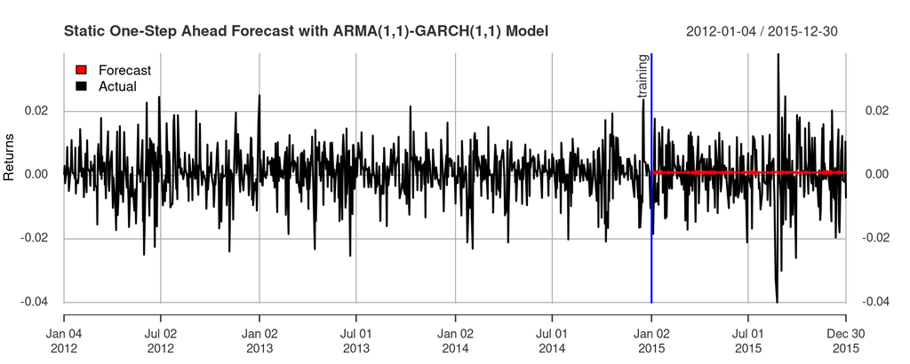

```r
### Plot Forecasts
# Returns
PlotReturns = cbind(xts(StaticForecast_Returns, order.by = index(Test)), Returns)
colnames(PlotReturns) <- c("Forecast", "Actual")

{plot(PlotReturns, col = c("red","black"), lwd = 2, ylab = "Returns",
     main = "Static One-Step Ahead Forecast with ARMA(1,1)-GARCH(1,1) Model", legend.loc = "topleft")
addEventLines(xts("training", index(Test)[1]), srt=90, pos=2, lwd = 2, col = "blue") }
```

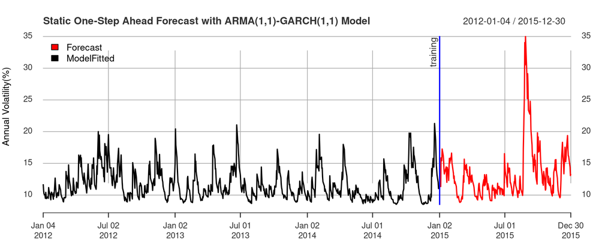

```r
# Volatility
PlotVolatility = cbind(xts(StaticForecast_Volatility, order.by = index(Test)), sigma(fit))
PlotVolatility = sqrt(252)*PlotVolatility
colnames(PlotVolatility) <- c("Forecast", "ModelFitted")
{plot(PlotVolatility*100, col = c("red","black"), lwd = 2, ylab = "Annual Volatility(%)",
     main = "Static One-Step Ahead Forecast with ARMA(1,1)-GARCH(1,1) Model", legend.loc = "topleft")
addEventLines(xts("training", index(Test)[1]), srt=90, pos=2, lwd = 2, col = "blue") }
```

```r
### MSE
MSE <- rbind("ARMA(1,1)-GARCH(1,1)" = c(mean((Returns - fitted(fit))**2,na.rm = T),
                              mean((Returns - PlotReturns$Forecast)**2, na.rm = T)))
colnames(MSE) <- c("In-sample MSE", "Out-of-sample MSE")
print(MSE)
```

```
##                      In-sample MSE Out-of-sample MSE
## ARMA(1,1)-GARCH(1,1)  5.445978e-05      9.622998e-05
```

### Rolling ARMA-GARCH

```r
rm(list=ls()) # clear workspace
cat("\014")  # clear console
```

```r
library(quantmod)

startd <-"2012-01-01"
endd <-"2015-12-31"
ticker <- "^GSPC"
Prices <- Ad(getSymbols(ticker, from = startd, to = endd, auto.assign = FALSE)) # get the adjusted closed price
Returns <- diff(log(Prices)) # get daily log-return
Returns <- na.omit(Returns)
names(Returns)<-"Actual Return"

# Split data
Train <- Returns["/2014"]
Test <- Returns["2015/"]
```

```r
### Specify Model: ARMA(1,1)-GARCH(1,1)
library(rugarch)
spec <- ugarchspec(variance.model=list(model="sGARCH", garchOrder=c(1,1)),
                   mean.model=list(armaOrder=c(1,1)),
                   distribution.model="norm")

# Estimate coefficients
fit <- ugarchfit(spec = spec, data = Returns, out.sample = length(Test)) # note that out-of-sample data is excluded by indicating out.sample = length(Test)
coef(fit)
```

```
##            mu           ar1           ma1         omega        alpha1
##  8.338512e-04 -9.283146e-01  9.152762e-01  7.559888e-06  1.540509e-01
##         beta1
##  7.149358e-01
```

```r
### Make Rolling 1-day ahead Forecast with ARMA(1,1)-GARCH(1,1) (Refitted the Model for Every 22 Steps). Continue for length(Test)=251 periods
RollForecast <- ugarchroll(spec, data = Returns, n.ahead = 1, forecast.length = length(Test), refit.every = 22, refit.window = "moving")

# Forecast for returns
RollForecast_Returns <- xts(RollForecast@forecast$density$Mu, index(Test))
data.frame(RollForecast_Returns)
```

```
##            RollForecast_Returns
## 2015-01-02         1.117649e-03
## 2015-01-05         5.894030e-04
## 2015-01-06         1.308984e-03
## 2015-01-07         5.263214e-04
## 2015-01-08         9.754379e-04
## 2015-01-09         4.839586e-04
## 2015-01-12         1.275007e-03
## 2015-01-13         5.469021e-04
## 2015-01-14         1.141025e-03
## 2015-01-15         6.395891e-04
## 2015-01-16         1.143666e-03
## 2015-01-20         3.872913e-04
## 2015-01-21         1.233256e-03
## 2015-01-22         4.176104e-04
## 2015-01-23         1.028110e-03
## 2015-01-26         7.387211e-04
## 2015-01-27         8.983478e-04
## 2015-01-28         9.614269e-04
## 2015-01-29         9.051161e-04
## 2015-01-30         6.557677e-04
## 2015-02-02         1.178224e-03
## 2015-02-03         3.616029e-04
## 2015-02-04         1.625222e-03
## 2015-02-05         1.809865e-03
## 2015-02-06         1.409982e-03
## 2015-02-09         1.567221e-03
## 2015-02-10         1.756249e-03
## 2015-02-11         1.341629e-03
## 2015-02-12         1.362412e-03
## 2015-02-13         9.937091e-04
## 2015-02-17         8.530166e-04
## 2015-02-18         8.138562e-04
## 2015-02-19         8.524076e-04
## 2015-02-20         9.207567e-04
## 2015-02-23         6.983909e-04
## 2015-02-24         7.378621e-04
## 2015-02-25         6.532154e-04
## 2015-02-26         7.119247e-04
## 2015-02-27         7.986911e-04
```

[output cut: 197 more lines]

```
## 2015-12-09         1.081656e-03
## 2015-12-10         1.144813e-03
## 2015-12-11         7.737738e-04
## 2015-12-14         1.549378e-03
## 2015-12-15         7.382639e-04
## 2015-12-16         3.986755e-04
## 2015-12-17         9.123487e-05
## 2015-12-18         1.483424e-03
## 2015-12-21         1.634047e-03
## 2015-12-22         4.234610e-04
## 2015-12-23         3.588722e-04
## 2015-12-24         1.899227e-04
## 2015-12-28         8.453282e-04
## 2015-12-29         8.814047e-04
## 2015-12-30         2.802300e-04
```

```r
# Forecast for volatility(sigma)
RollForecast_Volatility <- xts(RollForecast@forecast$density$Sigma, index(Test))
data.frame(RollForecast_Volatility)
```

```
##            RollForecast_Volatility
## 2015-01-02             0.007774226
## 2015-01-05             0.007148212
## 2015-01-06             0.009995892
## 2015-01-07             0.009754753
## 2015-01-08             0.009713575
## 2015-01-09             0.010874830
## 2015-01-12             0.010216451
## 2015-01-13             0.009787675
## 2015-01-14             0.008806689
## 2015-01-15             0.008396125
## 2015-01-16             0.008552831
## 2015-01-20             0.009096926
## 2015-01-21             0.008181170
## 2015-01-22             0.007568686
## 2015-01-23             0.009053744
## 2015-01-26             0.008528883
## 2015-01-27             0.007751099
## 2015-01-28             0.009074873
## 2015-01-29             0.009952155
## 2015-01-30             0.009472238
## 2015-02-02             0.010037878
## 2015-02-03             0.010034318
## 2015-02-04             0.010316210
## 2015-02-05             0.009467701
## 2015-02-06             0.009134006
## 2015-02-09             0.008443819
## 2015-02-10             0.008010210
## 2015-02-11             0.008130781
## 2015-02-12             0.007434538
## 2015-02-13             0.007611379
## 2015-02-17             0.007108921
## 2015-02-18             0.006613562
## 2015-02-19             0.006237996
## 2015-02-20             0.005982171
## 2015-02-23             0.006101415
## 2015-02-24             0.005842558
## 2015-02-25             0.005690135
## 2015-02-26             0.005547196
## 2015-02-27             0.005481564
```

[output cut: 197 more lines]

```
## 2015-12-09             0.009823775
## 2015-12-10             0.009381694
## 2015-12-11             0.008198147
## 2015-12-14             0.011621495
## 2015-12-15             0.010005688
## 2015-12-16             0.009694545
## 2015-12-17             0.010631410
## 2015-12-18             0.011433333
## 2015-12-21             0.013113618
## 2015-12-22             0.011404936
## 2015-12-23             0.010438437
## 2015-12-24             0.010487569
## 2015-12-28             0.009064254
## 2015-12-29             0.008060641
## 2015-12-30             0.008416029
```

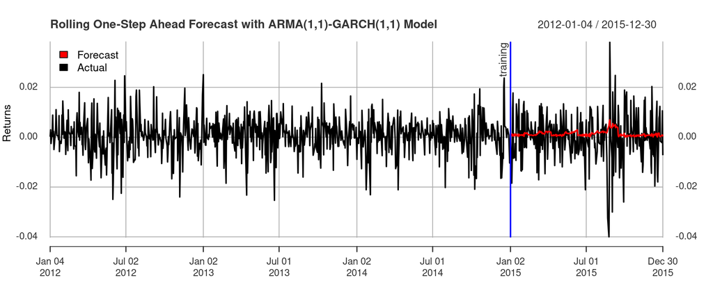

```r
### Plot Forecasts
# Returns
PlotReturns = cbind(RollForecast_Returns, Returns)
colnames(PlotReturns) <- c("Forecast", "Actual")

{plot(PlotReturns, col = c("red","black"), lwd = 2, ylab = "Returns",
     main = "Rolling One-Step Ahead Forecast with ARMA(1,1)-GARCH(1,1) Model", legend.loc = "topleft")
addEventLines(xts("training", index(Test)[1]), srt=90, pos=2, lwd = 2, col = "blue") }
```

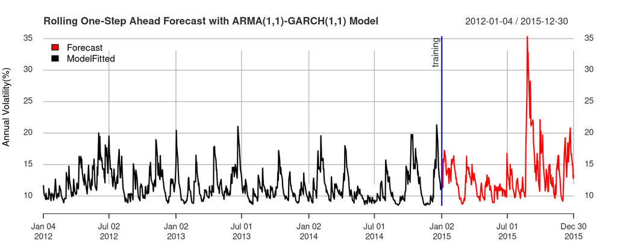

```r
# Volatility
PlotVolatility = cbind(RollForecast_Volatility, sigma(fit))
PlotVolatility = sqrt(252)*PlotVolatility
colnames(PlotVolatility) <- c("Forecast", "ModelFitted")

{plot(PlotVolatility*100, col = c("red","black"), lwd = 2, ylab = "Annual Volatility(%)",
     main = "Rolling One-Step Ahead Forecast with ARMA(1,1)-GARCH(1,1) Model", legend.loc = "topleft")
addEventLines(xts("training", index(Test)[1]), srt=90, pos=2, lwd = 2, col = "blue") }
```

```r
### MSE
MSE <- rbind("ARMA(1,1)-GARCH(1,1) Rolling" = c(mean((Returns - fitted(fit))**2,na.rm = T),
                              mean((Returns - RollForecast_Returns)**2, na.rm = T)))
colnames(MSE) <- c("In-sample MSE", "Out-of-sample MSE")
print(MSE)
```

```
##                              In-sample MSE Out-of-sample MSE
## ARMA(1,1)-GARCH(1,1) Rolling  5.445978e-05      9.747868e-05
```

### OOS Forecast Accuracy

```r
### Housekeeping
rm(list=ls()) # clear workspace
cat("\014")  # clear console
```

```r
library(quantmod)
startd<-"1990-01-01"
endd<-"2020-12-31"
Ticker = "GDPC1"
getSymbols(Ticker,from=startd,to=endd,src='FRED')
```

```
## [1] "GDPC1"
```

```r
Growth<-diff(log(GDPC1))
Growth<-na.omit(Growth)
colnames(Growth)=c("Growth")
# Split Data
Train <-Growth["/2014"]
Test<-Growth["2015/"]
```

```r
### Build Models
library(forecast)
fit <- auto.arima(Train)


### Make One-step Ahead Forecast by Feeding Test Data to Model
# Note that we included training data because the model needs historical data (Train) to make the first few predictions
fit.out <- Arima(Growth, model = fit)
# Extra one-step ahead forecasts over the test set
forecast.out <- subset(fitted(fit.out), start=length(Train)+1)
data.frame(OneStepForecast=forecast.out, row.names=as.yearqtr(index(Test)))
```

```
##         OneStepForecast
## 2015 Q1    0.0073023116
## 2015 Q2    0.0067954395
## 2015 Q3    0.0073812380
## 2015 Q4    0.0061770504
## 2016 Q1    0.0051017306
## 2016 Q2    0.0064978340
## 2016 Q3    0.0065027623
## 2016 Q4    0.0066713043
## 2017 Q1    0.0068783544
## 2017 Q2    0.0065590235
## 2017 Q3    0.0067785598
## 2017 Q4    0.0074984886
## 2018 Q1    0.0084136453
## 2018 Q2    0.0080566674
## 2018 Q3    0.0078099286
## 2018 Q4    0.0068937777
## 2019 Q1    0.0055157751
## 2019 Q2    0.0065067308
## 2019 Q3    0.0080190998
## 2019 Q4    0.0077474413
## 2020 Q1    0.0065888700
## 2020 Q2    0.0005585852
## 2020 Q3   -0.0281756907
## 2020 Q4    0.0137190738
## 2021 Q1    0.0273079139
## 2021 Q2    0.0083938289
## 2021 Q3    0.0082622226
## 2021 Q4    0.0085732439
## 2022 Q1    0.0101527974
```

```r
### Calculate Forecast Accuracy
# Train Sample
accuracy(fit)
```

```
##                        ME        RMSE         MAE       MPE     MAPE      MASE
## Training set 2.383421e-05 0.008819701 0.006511951 -215.3185 331.5274 0.7920155
##                    ACF1
## Training set 0.00248218
```

```r
# Test Sample
accuracy(forecast.out, Test) # the first input is the fitted/forecast value
```

```
##                    ME       RMSE        MAE       MPE     MAPE
## Test set -0.001846066 0.02628291 0.01031618 -8.837743 74.21872
```

### Diebold Mariano Test

The Diebold-Mariano test compares the forecast accuracy of two forecast methods.

#### In-Sample One-Step Forecast

```r
### Housekeeping
rm(list=ls()) # clear workspace
cat("\014")  # clear console
```

```r
### Load Data
library(Quandl)
Quandl_key = read.csv("quandlkey.csv",stringsAsFactors=FALSE)$Key
Quandl.api_key(Quandl_key)
startd<-"1990-01-01"
endd<-"2018-01-01"
freq<-"quarterly"
GDP <- Quandl("FRED/GDPC1", type="xts",start_date=startd, end_date=endd)
GDPGrowth <- diff(log(GDP)) # calculate log growth rate
GDPGrowth <- na.omit(GDPGrowth) # get rid of the NAs

### Make Forecasts
# Build models
Model1<-arima(GDPGrowth, order = c(1, 0, 0)) # fit an AR(1) model
Model2<-arima(GDPGrowth, order = c(0, 0, 3)) # fit an MA(3) model


### Apply DM Test to Model Residuals
# Extra residuals
M1Residuals <- Model1$residuals
M2Residuals <- Model2$residuals
# DM test on residuals
library(forecast)
dm.test(M1Residuals, M2Residuals, h=1) #h is the forecast horizon used in calculating residuals
```

```
##
##  Diebold-Mariano Test
##
## data:  M1ResidualsM2Residuals
## DM = 0.80227, Forecast horizon = 1, Loss function power = 2, p-value =
## 0.4241
## alternative hypothesis: two.sided
```

```r
# Interpret: High p-value -->  we cannot reject the null hypothesis that Model1 and Model2 have the same levels of accuracy over the training set
```

#### Out-of-Sample One-Step Forecast

```r
### Housekeeping
rm(list=ls()) # clear workspace
cat("\014")  # clear console
```

```r
### Load Data
library(Quandl)
Quandl_key = read.csv("quandlkey.csv",stringsAsFactors=FALSE)$Key
Quandl.api_key(Quandl_key)
startd<-"1990-01-01"
endd<-"2018-01-01"
freq<-"quarterly"
GDP <- Quandl("FRED/GDPC1", type="xts",start_date=startd, end_date=endd)
GDPGrowth <- diff(log(GDP)) # calculate log growth rate
GDPGrowth <- na.omit(GDPGrowth) # get rid of the NAs

# Split Data
Train <- GDPGrowth["/2014"]
Test <- GDPGrowth["2015/"]


### Build Models
Model1<-arima(Train, order = c(1, 0, 0)) # fit an AR(1) model
Model2<-arima(Train, order = c(0, 0, 3)) # fit an MA(3) model


### Make One-step Ahead Forecast by Feeding Test Data to Model
# Note that we included training data because the model needs historical data (Train) to make the first few predictions
library(forecast)
Model1.out <- Arima(GDPGrowth, model = Model1)
Model2.out <- Arima(GDPGrowth, model = Model2)


### Apply DM test
# Extra residuals over the test set
M1Residuals.out <- subset(Model1.out$residuals, start=length(Train)+1)
M2Residuals.out <- subset(Model2.out$residuals, start=length(Train)+1)
# DM test on residuals
dm.test(M1Residuals.out,M2Residuals.out, h = 1)
```

```
##
##  Diebold-Mariano Test
##
## data:  M1Residuals.outM2Residuals.out
## DM = 1.0293, Forecast horizon = 1, Loss function power = 2, p-value =
## 0.3236
## alternative hypothesis: two.sided
```

```r
# Interpret: High p-value -->  we cannot reject the null hypothesis that Model1 and Model2 have the same levels of forecast accuracy over the test set
```

### NNETAR One-Step Ahead

```r
### Housekeeping
rm(list=ls()) # clear workspace
cat("\014")  # clear console
```

```r
### Load data
library(Quandl)
Quandl_key = read.csv("quandlkey.csv",stringsAsFactors=FALSE)$Key
Quandl.api_key(Quandl_key)
startd<-"1990-01-01"
endd<-"2018-12-31"
freq<-"quarterly"
GDP <- Quandl("FRED/GDPC1", type="ts",start_date=startd, end_date=endd)
GDPGrowth <- diff(log(GDP)) # calculate log growth rate
GDPGrowth <- na.omit(GDPGrowth) # get rid of the NAs

# Split data
Train <- window(GDPGrowth,  end = 2014.9999)
Test <- window(GDPGrowth,  start = 2015)
```

```r
### One-Step Ahead Forecasts with NNETAR model
library(forecast)
set.seed(123)
fit <- nnetar(Train)
fit
```

```
## Series: Train
## Model:  NNAR(14,1,8)[4]
## Call:   nnetar(y = Train)
##
## Average of 20 networks, each of which is
## a 14-8-1 network with 129 weights
## options were - linear output units
##
## sigma^2 estimated as 2.091e-09
```

```r
NNETARForecast <- forecast(fit, h = 1, PI=FALSE) # h is the forecast period number; set PI = TRUE to calculate the prediction intervals(take some time)
data.frame(PointForecast=NNETARForecast$mean, row.names=as.yearqtr(index(Test)[1]))
```

```
##         PointForecast
## 2015 Q1   0.004302383
```

The above command will only give you the first one-step-ahead forecast, if you want to forecast for all out-of-sample period you can refit the model with testing data:

```r
### Make Forecasts Over The Whole Test Set
fit.out <- nnetar(Test, model = fit) # Note that the length of the test data must be greater than the data frequency (4) or the maximum order of NNETAR (14), whichever is greater
NNETARForecast.out <- fitted(fit.out)
data.frame(OneStepForecast=NNETARForecast.out, row.names=as.yearqtr(index(Test)))
```

```
##         OneStepForecast
## 2015 Q1              NA
## 2015 Q2              NA
## 2015 Q3              NA
## 2015 Q4              NA
## 2016 Q1              NA
## 2016 Q2              NA
## 2016 Q3              NA
## 2016 Q4              NA
## 2017 Q1              NA
## 2017 Q2              NA
## 2017 Q3              NA
## 2017 Q4              NA
## 2018 Q1              NA
## 2018 Q2              NA
## 2018 Q3     0.008899046
## 2018 Q4     0.004010705
```

```r
# Note that you can't get the first few (14) fitted values that way because the second call to nnetar knows nothing about the earlier data. This problem can be solved by refitting the model with training and testing data together:
fit.out2 <- nnetar(GDPGrowth, model = fit)
NNETARForecast.out2 <- subset(fitted(fit.out2), start=length(Train)+1)
data.frame(OneStepForecast=NNETARForecast.out2, row.names=as.yearqtr(index(Test)))
```

```
##         OneStepForecast
## 2015 Q1    0.0043023825
## 2015 Q2    0.0112161243
## 2015 Q3    0.0027718595
## 2015 Q4    0.0044836787
## 2016 Q1    0.0126382375
## 2016 Q2   -0.0001183569
## 2016 Q3   -0.0035165914
## 2016 Q4    0.0132423986
## 2017 Q1    0.0030158720
## 2017 Q2   -0.0023111000
## 2017 Q3    0.0002952316
## 2017 Q4    0.0074882225
## 2018 Q1    0.0064936085
## 2018 Q2    0.0083218970
## 2018 Q3    0.0088990458
## 2018 Q4    0.0040107055
```

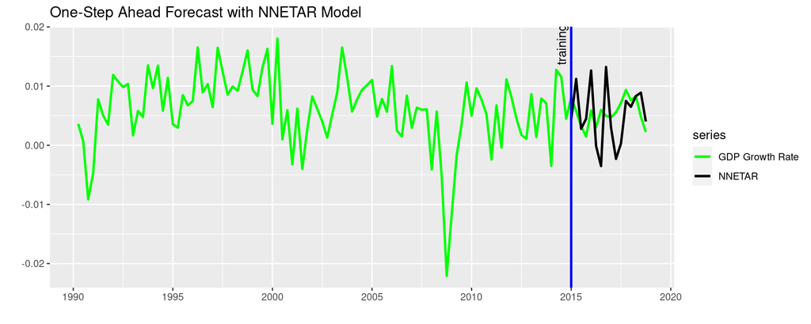

```r
### Plot Forecasts
library(ggplot2)
CutDate <- tsp(Test)[1] #test sample start time
autoplot(GDPGrowth, series = "GDP Growth Rate", lwd = 1) +
  autolayer(NNETARForecast.out2, series="NNETAR",lwd = 1) +
  geom_vline(xintercept = CutDate, lwd = 1,color = "blue") +
  annotate("text", x = CutDate - 1/2, y = 0.017,srt=90, label = "training") +
  scale_color_manual(values = c("green","black")) +
  ylab("") + xlab("") + ggtitle("One-Step Ahead Forecast with NNETAR Model")
```

```r
### MSE
MSE <- rbind("NNETAR" = c(mean((GDPGrowth - fit$fitted)**2,na.rm = T),
                          mean((GDPGrowth - NNETARForecast.out2)**2, na.rm = T)))
colnames(MSE) <- c("In-sample MSE", "Out-of-sample MSE")
print(MSE)
```

```
##        In-sample MSE Out-of-sample MSE
## NNETAR  2.090753e-09      2.531095e-05
```